# 2024_BigFive_IA

Análises psicométricas

Published

September 13, 2026

# Carregar pacotes

```r
pacman::p_load(tidyverse,psych,lavaan,writexl,qgraph,pander,readr,readxl,knitr,openxlsx,httr,jsonlite,caret,e1071,Matrix)
# install.packages("Matrix")
citation("httr")
```

```
Para citar o pacote 'httr' em publicações use:

  Wickham H (2026). _httr: Tools for Working with URLs and HTTP_.
  doi:10.32614/CRAN.package.httr
  <https://doi.org/10.32614/CRAN.package.httr>. R package version
  1.4.8, <https://CRAN.R-project.org/package=httr>.

Uma entrada BibTeX para usuários(as) de LaTeX é

  @Manual{,
    title = {httr: Tools for Working with URLs and HTTP},
    author = {Hadley Wickham},
    year = {2026},
    note = {R package version 1.4.8},
    url = {https://CRAN.R-project.org/package=httr},
    doi = {10.32614/CRAN.package.httr},
  }
```

```r
citation("jsonlite")
```

```
  Ooms J (2014). "The jsonlite Package: A Practical and Consistent
  Mapping Between JSON Data and R Objects." _arXiv:1403.2805
  [stat.CO]_. <https://arxiv.org/abs/1403.2805>.

Uma entrada BibTeX para usuários(as) de LaTeX é

  @Article{,
    title = {The jsonlite Package: A Practical and Consistent Mapping Between JSON Data and R Objects},
    author = {Jeroen Ooms},
    journal = {arXiv:1403.2805 [stat.CO]},
    year = {2014},
    url = {https://arxiv.org/abs/1403.2805},
  }
```

```r
citation("ltm")
```

```
  Dimitris Rizopoulos (2006). ltm: An R package for Latent Variable
  Modelling and Item Response Theory Analyses, Journal of Statistical
  Software, 17 (5), 1-25. URL https://doi.org/10.18637/jss.v017.i05

Uma entrada BibTeX para usuários(as) de LaTeX é

  @Article{,
    title = {ltm: An R package for Latent Variable Modelling and Item Response Theory Analyses},
    author = {Dimitris Rizopoulos},
    journal = {Journal of Statistical Software},
    year = {2006},
    volume = {17},
    number = {5},
    pages = {1--25},
    url = {https://doi.org/10.18637/jss.v017.i05},
  }
```

```r
citation("psych")
```

```
Para citar o pacote 'psych' em publicações use:

  William Revelle (2026). _psych: Procedures for Psychological,
  Psychometric, and Personality Research_. Northwestern University,
  Evanston, Illinois. R package version 2.6.4,
  <https://CRAN.R-project.org/package=psych>.

Uma entrada BibTeX para usuários(as) de LaTeX é

  @Manual{,
    title = {psych: Procedures for Psychological, Psychometric, and Personality Research},
    author = {{William Revelle}},
    organization = {Northwestern University},
    address = {Evanston, Illinois},
    year = {2026},
    note = {R package version 2.6.4},
    url = {https://CRAN.R-project.org/package=psych},
  }
```

```r
citation("caret")
```

```
  Kuhn, M. (2008). Building Predictive Models in R Using the caret
  Package. Journal of Statistical Software, 28(5), 1–26.
  https://doi.org/10.18637/jss.v028.i05

Uma entrada BibTeX para usuários(as) de LaTeX é

  @Article{,
    title = {Building Predictive Models in R Using the caret Package},
    volume = {28},
    url = {https://www.jstatsoft.org/index.php/jss/article/view/v028i05},
    doi = {10.18637/jss.v028.i05},
    number = {5},
    journal = {Journal of Statistical Software},
    author = {{Kuhn} and {Max}},
    year = {2008},
    pages = {1–26},
  }
```

```r
citation()
```

```
  R Core Team (2026). _R: A Language and Environment for Statistical
  Computing_. R Foundation for Statistical Computing, Vienna, Austria.
  doi:10.32614/R.manuals <https://doi.org/10.32614/R.manuals>.
  <https://www.R-project.org/>.

Uma entrada BibTeX para usuários(as) de LaTeX é

  @Manual{,
    title = {R: A Language and Environment for Statistical Computing},
    author = {{R Core Team}},
    organization = {R Foundation for Statistical Computing},
    address = {Vienna, Austria},
    year = {2026},
    doi = {10.32614/R.manuals},
    url = {https://www.R-project.org/},
  }

We have invested a lot of time and effort in creating R, please cite it
when using it for data analysis. See also 'citation("pkgname")' for
citing R packages.
```

# Importar banco de dados

```r
# importar banco de dados para o diretório do seu computador.
# Salve no diretório que for utilizar para realizar as análises.
df1 <- read.csv(
  "https://raw.githubusercontent.com/jmhbueno/BigFive_IA/main/dataset_pibic_2024_bigfive.csv"
)

# Dataframe completo
df1$id <- paste0("s",1:nrow(df1))

# dicionário bfbr
bfbr_dic <- read.csv2(
  "https://raw.githubusercontent.com/jmhbueno/BigFive_IA/main/bf_br_dic.csv"
)

# dicionário bfi2
bfi2_dic <- read.csv2(
  "https://raw.githubusercontent.com/jmhbueno/BigFive_IA/main/bfi2_dic.csv"
)


# todos os itens
itens <- bind_rows(
  select(bfbr_dic, coditem, scale, pole, txt_item, ordem),
  select(bfi2_dic, coditem, scale, pole, txt_item, ordem))
```

# Análise das classificações dos itens pelo prompt do Gemini

Instruções dadas ao Gemini: Você fará o papel de um juiz especialista em teorias da personalidade, especialmente no que se refere ao modelo dos cinco grandes fatores, que é uma das teorias do traço. Considere que os cinco grandes fatores são: extroversão, amabilidade, conscienciosidade, neuroticismo e abertura. Esses traços são subdivididos em três facetas cada um:

- Extroversão: sociabilidade, assertividade e nível de energia
- Amabilidade: compaixão, respeito e confiança
- Conscienciosidade: organização, produtividade e responsabilidade
- Neuroticismo: ansiedade, depressão e labilidade emocional
- Abertura: curiosidade intelectual, sensibilidade estética e imaginação criativa

Faça duas classificações para cada item: em um dos cinco fatores e em uma das três facetas do fator classificado. Apresente os resultados em uma tabela com três colunas: itens, classificação dos fatores, classificação das facetas.

```r
# Transformações de variáveis em fator

## Classificação dos cinco grandes
bfbr_dic$gemini_fator <- factor(bfbr_dic$gemini_fator,
                                 levels = c("Extroversão", "Amabilidade", "Conscienciosidade", "Neuroticismo", "Abertura"))

## Calssificação das facetas
bfbr_dic$gemini_faceta <- factor(bfbr_dic$gemini_faceta,
                                  levels = c("Sociabilidade", "Assertividade", "Nível de Energia",
                                             "Compaixão", "Respeito", "Confiança",
                                             "Organização","Produtividade","Responsabilidade",
                                             "Ansiedade","Depressão","Labilidade Emocional",
                                             "Curiosidade Intelectual","Sensibilidade Estética","Imaginação Criativa"))
## Codificação das facetas
bfbr_dic$scale <- factor(bfbr_dic$scale,
                         levels = c("E_soc", "E_ass", "E_ene",
                                    "A_com", "A_res", "A_con",
                                    "C_org","C_pro","C_res",
                                    "N_ans","N_dep","N_lab",
                                    "O_cur","O_sen","O_ima"))

bfi2_dic$scale <- factor(bfi2_dic$scale,
                         levels = c("E_soc","E_ass","E_ene",
                                    "A_com","A_res","A_con",
                                    "C_org","C_pro","C_res",
                                    "N_ans","N_dep","N_lab",
                                    "O_cur","O_sen","O_ima"))


table1 <- table(bfbr_dic$scale,bfbr_dic$gemini_fator)
table2 <- table(bfbr_dic$scale,bfbr_dic$gemini_faceta)

class_fator <- table1 %>% as.data.frame()
class_facet <- table2 %>% as.data.frame()

class_fator <-
class_fator %>% rename(class_expec = Var1,
                       gemini_fator = Var2)
class_fator <- class_fator %>% filter(Freq != 0)

class_facet <-
class_facet %>% rename(class_expec = Var1,
                       gemini_facet = Var2)

class_facet <- class_facet %>% filter(Freq != 0)

write_xlsx(class_fator %>% mutate("%" = Freq*100/8),"class_fator.xlsx")
write_xlsx(class_facet %>% mutate("%" = Freq*100/8),"class_facet.xlsx")
```

# Embeddings - Função

OBS: Você precisará criar uma API_KEY no Gemini e colá-la no campo `api_key_gemini <- ["COLE SUA GEMINI_API_KEY AQUI"]` do chunk abaixo.

```r
# Pacotes -----------------------------------------------------------------

library(httr)
library(jsonlite)

# API Keys ----------------------------------------------------------------

# Sua chave de API do Gemini
api_key_gemini <- ["COLE SUA GEMINI_API_KEY AQUI"]


# Funções -----------------------------------------------------------------

#' Função para capturar embeddings da Gemini
#' Aceita só textos individuais
#' @param api_key É a chave da API
#' @param texto É um texto para ser transformado em embeddings
#' @param model é o modelo que será utilizado (recomenda-se `models/text-embedding-004` em 2024)
get_embeddings_gemini <- function(api_key, text, model) {
    require('httr','jsonlite')
    url <- paste0("https://generativelanguage.googleapis.com/v1beta/models/text-embedding-004:embedContent?key=", api_key)

    # Configura o cabeçalho da solicitação
    headers <- httr::add_headers(
        `Content-Type` = "application/json"
    )

   body <- list(
        model = model,
        content = list(
            parts = list(
                list(text = text)
            )
        )
    )

    # Faz a solicitação POST
    response <- httr::POST(url, headers, body = jsonlite::toJSON(body, auto_unbox = TRUE))

    # Verifica se a solicitação foi bem-sucedida
    if (response$status_code != 200) {
        stop("Erro na solicitação: ", response$status_code, "\n", httr::content(response, "text"))
    }

    # Parseia a resposta JSON
    response_content <- httr::content(response, "parsed", simplifyVector = TRUE)

    # Retorna os embeddings
    return(response_content$embedding$values)
}
```

# Embeddings todos os itens (bfbr e bfi2) (Gemini)

```r
# Caso queira capturar os embeddings de linhas de um data-frame, usar:
# Cria uma lista de embeddings
embeddings_gemini <- list()
# Faz um loop para captura
for(i in 1:length(itens$txt_item)){
  print(paste0('Buscando embedding ', i))
  embeddings_gemini[[i]] <- get_embeddings_gemini(
    api_key = api_key_gemini,
    text = itens$txt_item[i],
    model = 'models/text-embedding-004'
  )
}

# Transformar em dataframe
embeddings_items_gemini <- do.call(rbind, embeddings_gemini)
embeddings_items_gemini <- as.data.frame(embeddings_items_gemini)

write.csv(
  df5,
  "embeddings_items_gemini.csv",
  row.names = FALSE
)
```

# Seleção de embeddings (Gemini) pela correlação com o fator

É possível que os embeddigns capturados com os códigos acima, sejam ligeiramente diferentes dos que foram utilizados nas análises. Por isso, também disponibilizo o banco com os embeddings que utilizei.

```r
# Opção 1: baixar embeddings utilizados no artigo. Se utilizar este, pule o comando da linha 296.

df5 <- read.csv(
  "https://raw.githubusercontent.com/jmhbueno/BigFive_IA/main/embeddings_items_gemini.csv")

# OU, utilize os comandos que você gerou com os códigos do chunck anterior, que podem ser ligeiramente diferentes dos que foram utilizados no artigo.
# OBS.: o código abaixo está desativado. Para ativá-lo, retire o # do inicio da linha.

# df5 <- embeddings_items_gemini


# Seja por uma ou outra via, continue por aqui
id = paste(itens$coditem, itens$scale, sep="_")
df5$id = id

# Criar variáveis dummy
df5_dummies <- dummy.code(str_sub(itens$scale, 1, 1)) # str_sub extrai a 1ª letra de cada linha

df5 <- cbind(df5_dummies,df5)
df5 = df5 %>% select(id,E,A,C,N,A,everything())
write_xlsx(df5,"df5.xlsx")

# Selecionar as variáveis de V1 a V768
V_vars <- df5[, paste0("V", 1:768)]


extr <- df5$E
amab <- df5$A
cons <- df5$C
neur <- df5$N
aber <- df5$O

# Função para calcular a correlação ponto bisserial entre uma variável contínua e uma dummy
cor_ponto_bisserial <- function(x, y) {
  ltm::biserial.cor(x, y, use = "complete.obs")
}

# Calcular as correlações ponto bisserial para cada fator (extr, amab, cons, neur, aber)
cor_gemini_extr <- apply(V_vars, 2, function(x) cor_ponto_bisserial(x, extr))
cor_gemini_amab <- apply(V_vars, 2, function(x) cor_ponto_bisserial(x, amab))
cor_gemini_cons <- apply(V_vars, 2, function(x) cor_ponto_bisserial(x, cons))
cor_gemini_neur <- apply(V_vars, 2, function(x) cor_ponto_bisserial(x, neur))
cor_gemini_aber <- apply(V_vars, 2, function(x) cor_ponto_bisserial(x, aber))
# ------------------------------------------------------------------------------
# juntar as correlações em um dataframe
df5_cor = cbind(cor_gemini_extr,cor_gemini_amab,cor_gemini_cons,cor_gemini_neur,cor_gemini_aber) %>% as.data.frame()

# Calcular as médias e desvios padrão para cada variável
me_gemini_extr <- mean(df5_cor$cor_gemini_extr)
dp_gemini_extr <- sd(df5_cor$cor_gemini_extr)
me_gemini_amab <- mean(df5_cor$cor_gemini_amab)
dp_gemini_amab <- sd(df5_cor$cor_gemini_amab)
me_gemini_cons <- mean(df5_cor$cor_gemini_cons)
dp_gemini_cons <- sd(df5_cor$cor_gemini_cons)
me_gemini_neur <- mean(df5_cor$cor_gemini_neur)
dp_gemini_neur <- sd(df5_cor$cor_gemini_neur)
me_gemini_aber <- mean(df5_cor$cor_gemini_aber)
dp_gemini_aber <- sd(df5_cor$cor_gemini_aber)

# Limites empregados
me_gemini_extr + 2*dp_gemini_extr
```

```
[1] 0.2430051
```

```r
me_gemini_extr - 2*dp_gemini_extr
```

```
[1] -0.2339453
```

```r
me_gemini_amab + 2*dp_gemini_amab
```

```
[1] 0.3567559
```

```r
me_gemini_amab - 2*dp_gemini_amab
```

```
[1] -0.3465218
```

```r
me_gemini_cons + 2*dp_gemini_cons
```

```
[1] 0.3446048
```

```r
me_gemini_cons - 2*dp_gemini_cons
```

```
[1] -0.3593912
```

```r
me_gemini_neur + 2*dp_gemini_neur
```

```
[1] 0.4075048
```

```r
me_gemini_neur - 2*dp_gemini_neur
```

```
[1] -0.4054898
```

```r
me_gemini_aber + 2*dp_gemini_aber
```

```
[1] 0.400009
```

```r
me_gemini_aber - 2*dp_gemini_aber
```

```
[1] -0.4065314
```

```r
# Selecionar as linhas onde os valores estão acima de 1 desvio padrão acima da média
# ou abaixo de 1 desvio padrão abaixo da média
df5_cor_selecionado <- df5_cor[
  (df5_cor$cor_gemini_extr > (me_gemini_extr + 2*dp_gemini_extr) | df5_cor$cor_gemini_extr < (me_gemini_extr - 2*dp_gemini_extr)) |
  (df5_cor$cor_gemini_amab > (me_gemini_amab + 2*dp_gemini_amab) | df5_cor$cor_gemini_amab < (me_gemini_amab - 2*dp_gemini_amab)) |
  (df5_cor$cor_gemini_cons > (me_gemini_cons + 2*dp_gemini_cons) | df5_cor$cor_gemini_cons < (me_gemini_cons - 2*dp_gemini_cons)) |
  (df5_cor$cor_gemini_neur > (me_gemini_neur + 2*dp_gemini_neur) | df5_cor$cor_gemini_neur < (me_gemini_neur - 2*dp_gemini_neur)) |
  (df5_cor$cor_gemini_aber > (me_gemini_aber + 2*dp_gemini_aber) | df5_cor$cor_gemini_aber < (me_gemini_aber - 2*dp_gemini_aber))
, ]

# Transformar o índice (nomes das linhas) em uma coluna do dataframe
df5_cor_selecionado <- rownames_to_column(df5_cor_selecionado, var = "embeddings")
lista_embeddings_gemini <- df5_cor_selecionado$embeddings

df5_efa <- df5 %>% select(all_of(lista_embeddings_gemini))

# transpor matriz
df5_efa <- t(df5_efa)

# trasnformação em dataframe
df5_efa <- as.data.frame(df5_efa)

# Inserção dos nomes das variáveis, para facilitar a interpretação
colnames(df5_efa) <- paste(itens$coditem,itens$scale,sep = "_")
```

# EFA de todos os itens juntos (bfbr + bfi) / Embeddings (Gemini) selecionados por correlação

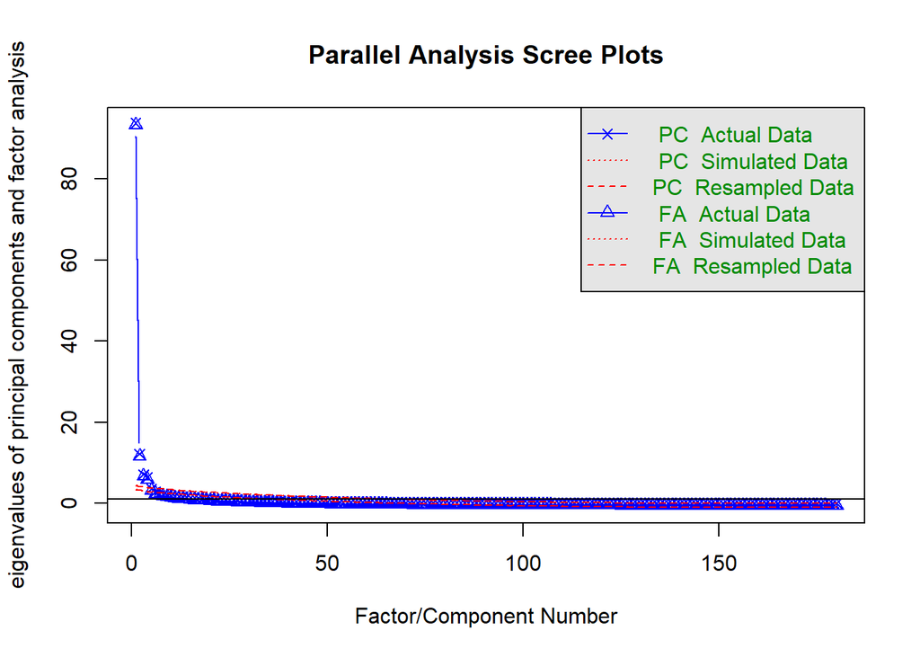

```
Parallel analysis suggests that the number of factors =  5  and the number of components =  4
```

```r
# EFA a partir da seleção de embeddings com correlações ponto bisseriais
parallel_analysis <- fa.parallel(df5_efa)
```

```r
efa6 <- fa(df5_efa, nfactors = 5, rotate = "varimax", )
print.psych(efa6,cut = 0.3)
```

```
Factor Analysis using method =  minres
Call: fa(r = df5_efa, nfactors = 5, rotate = "varimax")
Standardized loadings (pattern matrix) based upon correlation matrix
                MR2  MR1  MR4   MR3   MR5   h2   u2 com
bf_br1_E_soc        0.49 0.37        0.54 0.76 0.24 3.4
bf_br2_E_soc   0.39 0.52 0.34        0.41 0.70 0.30 3.6
bf_br3_E_soc   0.48                  0.58 0.73 0.27 3.0
bf_br4_E_soc   0.33 0.38 0.47        0.42 0.69 0.31 4.1
bf_br5_E_soc        0.47 0.37        0.51 0.73 0.27 3.8
bf_br6_E_soc        0.33 0.46        0.45 0.62 0.38 3.7
bf_br7_E_soc        0.44 0.30        0.34 0.54 0.46 4.1
bf_br8_E_soc   0.61 0.36             0.36 0.72 0.28 2.9
bf_br9_E_ass   0.46 0.46 0.31        0.31 0.64 0.36 3.7
bf_br10_E_ass  0.32 0.37 0.31  0.41       0.54 0.46 4.2
bf_br11_E_ass  0.37 0.37       0.44  0.37 0.65 0.35 4.4
bf_br12_E_ass       0.53       0.38  0.40 0.73 0.27 3.9
bf_br13_E_ass  0.51 0.48                  0.64 0.36 3.2
bf_br14_E_ass       0.32       0.32  0.51 0.58 0.42 3.5
bf_br15_E_ass  0.45 0.49                  0.63 0.37 3.5
bf_br16_E_ass  0.50 0.42 0.31        0.42 0.70 0.30 3.7
bf_br17_E_ene  0.58            0.40  0.31 0.66 0.34 2.8
bf_br18_E_ene  0.71                       0.71 0.29 1.9
bf_br19_E_ene  0.52                  0.36 0.55 0.45 3.1
bf_br20_E_ene       0.34 0.47  0.41  0.36 0.67 0.33 4.1
bf_br21_E_ene  0.70      0.30  0.34       0.71 0.29 1.9
bf_br22_E_ene  0.71 0.35                  0.72 0.28 2.0
bf_br23_E_ene  0.60                       0.63 0.37 2.6
bf_br24_E_ene  0.58            0.42       0.62 0.38 2.7
bf_br25_A_com  0.50 0.66                  0.73 0.27 2.1
bf_br26_A_com       0.63 0.42             0.71 0.29 2.6
bf_br27_A_com  0.57 0.61                  0.74 0.26 2.3
bf_br28_A_com       0.71                  0.67 0.33 1.7
bf_br29_A_com  0.35 0.62 0.30        0.34 0.74 0.26 2.9
bf_br30_A_com  0.37 0.52       0.38       0.57 0.43 3.0
bf_br31_A_com  0.31 0.74                  0.77 0.23 1.9
bf_br32_A_com       0.57 0.41  0.36       0.70 0.30 3.2
bf_br33_A_res       0.72 0.34             0.72 0.28 1.8
bf_br34_A_res       0.64 0.33  0.39       0.68 0.32 2.3
bf_br35_A_res  0.37 0.65                  0.71 0.29 2.5
bf_br36_A_res  0.40 0.55 0.34             0.66 0.34 3.2
```

[output cut: 158 more lines]

```
The root mean square of the residuals (RMSR) is  0.04
The df corrected root mean square of the residuals is  0.04

The harmonic n.obs is  140 with the empirical chi square  3265.37  with prob <  1
The total n.obs was  140  with Likelihood Chi Square =  4992.37  with prob <  1

Tucker Lewis Index of factoring reliability =  1.016
RMSEA index =  0  and the 90 % confidence intervals are  0 0
BIC =  -70219.43
Fit based upon off diagonal values = 0.99
Measures of factor score adequacy
                                                   MR2  MR1  MR4  MR3  MR5
Correlation of (regression) scores with factors   0.99 0.98 0.99 0.98 0.96
Multiple R square of scores with factors          0.98 0.97 0.97 0.96 0.92
Minimum correlation of possible factor scores     0.97 0.94 0.94 0.93 0.84
```

```r
efa6_str_gemini <- as.data.frame(unclass(efa6$loadings))
efa6_str_gemini$coditem <- itens$coditem
efa6_str_gemini$scale <- itens$scale
efa6_str_gemini$txt_item <- itens$txt_item
efa6_str_gemini = efa6_str_gemini %>% select(coditem,scale,txt_item,everything())

write_xlsx(efa6_str_gemini, "efa6_str_gemini.xlsx")

# Por sugestão do revisor, utilizar rotação promax (análise reportada no artigo)
efa6a <- fa(df5_efa, nfactors = 5, rotate = "promax")

efa6a_str_gemini <- as.data.frame(unclass(efa6a$loadings))
efa6a_str_gemini$coditem <- itens$coditem
efa6a_str_gemini$scale <- itens$scale
efa6a_str_gemini$txt_item <- itens$txt_item
efa6a_str_gemini = efa6a_str_gemini %>% select(coditem,scale,txt_item,everything())

write_xlsx(efa6a_str_gemini, "efa6a_str_gemini.xlsx")
```

OBS.: A tabela de cargas fatoriais apresentada no artigo, foi obtida pelo cálculo das médias das cargas fatoriais dos itens em cada fator, como informado no artigo. Isso foi feito no próprio arquivo do excel. Se quiser baixar esse arquivo, rode o código a seguir. Você precisará definir o nome completo do arquivo, inlcuindo a extensão `.xlsx`.

```r
url <- "https://raw.githubusercontent.com/jmhbueno/BigFive_IA/main/efa6a_str_gemini_com_medias.xlsx"

destino <- file.choose(new = TRUE)

download.file(
  url = url,
  destfile = destino,
  mode = "wb"
)
```

# Análise de congruência

```r
# cargas nos cinco fatores
congruence_analysis <- as.data.frame(unclass(efa6a$loadings))

df6a_dummies <- dummy.code(itens$scale)

congruence_analysis <- cbind(congruence_analysis,df6a_dummies)

congruence_analysis <- rownames_to_column(congruence_analysis,var = "Facetas")

# Análise de congruência
names(congruence_analysis)
```

```
 [1] "Facetas" "MR2"     "MR1"     "MR4"     "MR3"     "MR5"     "A_com"
 [8] "A_con"   "A_res"   "C_org"   "C_pro"   "C_res"   "E_ass"   "E_ene"
[15] "E_soc"   "N_ans"   "N_dep"   "N_lab"   "O_cur"   "O_ima"   "O_sen"
```

```r
factor.congruence(congruence_analysis[,7:21],congruence_analysis[,2:6])
```

```
        MR2   MR1   MR4   MR3   MR5
A_com  0.11  0.43  0.00 -0.02  0.09
A_con  0.04  0.53  0.03  0.00 -0.06
A_res  0.00  0.48  0.03  0.03  0.07
C_org  0.04  0.00  0.09  0.56  0.02
C_pro  0.05  0.06  0.03  0.52  0.07
C_res  0.10  0.20 -0.03  0.39  0.00
E_ass  0.10  0.22  0.03  0.05  0.38
E_ene  0.30 -0.06  0.03  0.16  0.30
E_soc  0.12  0.13  0.07 -0.01  0.54
N_ans  0.44  0.09  0.01  0.08 -0.11
N_dep  0.45  0.05  0.02  0.01 -0.03
N_lab  0.48 -0.02  0.00  0.03  0.10
O_cur  0.05  0.08  0.52 -0.03  0.06
O_ima  0.09 -0.04  0.63  0.03 -0.06
O_sen -0.03  0.10  0.42  0.11  0.13
```